# Convert a NumPy array to LaTeX

- Show All Code
- Hide All Code
- View Source

LaTeX matrices and determinants from NumPy arrays

Python

Numpy

Latex

Determinant

Author

[Enrique Pérez Herrero](https://github.com/EnriquePH)

Published

August 2, 2023

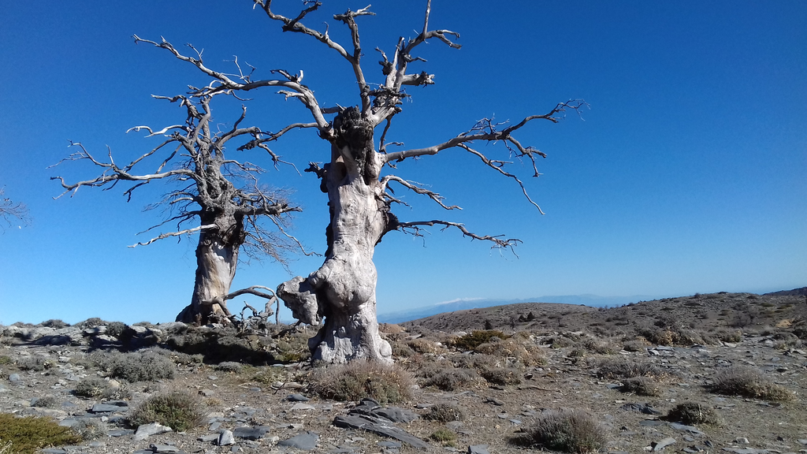

Sierra de las Nieves (Málaga)

# 1 Convert Numpy array to $LaTeX$

Sometimes, when you are writing a statistics or a math article, you must go through a tedious process of typing and testing numerous lines of text until your code works. This can be especially boring when dealing with long matrices. If you want to improve your productivity, automating this process comes in very handy, and [Python](https://www.python.org/) is particularly useful for that.

## 1.1 Functions for matrices and determinants

The functions `matrix2latex` and `det2latex` generate an indented $LaTeX$ string that can be copied or directly rendered in your math article.

The `INDENT_SPACES` parameter specifies the number of spaces used for indentation.

```python
import numpy as np

INDENT_SPACES = 3

def indent(num_indent=1):
    """
    Number of spaces for indentation
    """
    return num_indent * INDENT_SPACES * " "

def matrix2latex(matrix):
    """
    Convert a NumPy array to LaTeX code as a matrix
    """
    left_latex = r"\left(" + "\n" + indent(1) + r"\begin{array}"
    right_latex = indent(1) + r"\end{array}" + "\n" + r"\right)"
    m_cols = matrix.shape[1]
    array_cols = "{" + "r" * m_cols + "}\n"
    elements_latex = ""
    for row in matrix:
        elements_latex = \
          elements_latex + indent(2) + " & ".join([str(x) for x in row]) + \
            r" \\ " + "\n"
    latex = left_latex + array_cols + elements_latex + right_latex
    return f"$$\n{latex}\n$$"

def det2latex(matrix):
    """
    Convert a NumPy array to LaTeX code as a determinant
    """
    left_latex = r"\begin{vmatrix}" + "\n"
    right_latex = r"\end{vmatrix}"
    m_cols = matrix.shape[1]
    elements_latex = ""
    for row in matrix:
        elements_latex = \
          elements_latex + indent(1) + " & ".join([str(x) for x in row]) + \
            r" \\ " + "\n"
    latex = left_latex + elements_latex + right_latex
    return f"$$\n{latex}\n$$"
```

### 1.1.1 Output string

Using the [NumPy](https://numpy.org/) function `np.eye`, we can create an identity matrix of the desired dimensions, making it a convenient tool for testing our functions.

```python
print(matrix2latex(np.eye(3, dtype=int)))
```

```
$$
\left(
   \begin{array}{rrr}
      1 & 0 & 0 \\
      0 & 1 & 0 \\
      0 & 0 & 1 \\
   \end{array}
\right)
$$
```

## 1.2 Rendering output in a document

If you are working in a [Jupyter](https://jupyter.org/) notebook, you can render a $LaTeX$ string using the `Math` function from the `IPython` library, which can be imported as follows:

```python
from IPython.display import Math
```

If you are writing a `Python` chunk in a `Quarto` file in [RStudio](https://posit.co/download/rstudio-desktop/), you need to include the option `#| output: asis` at the top of the code chunk. This option determines how the output is rendered in the final document.

```python
print(det2latex(np.eye(3, dtype=int)))
```

$$\begin{vmatrix}
1 & 0 & 0 \\
0 & 1 & 0 \\
0 & 0 & 1 \\
\end{vmatrix}$$

```python
# Identity 4x4 matrix
identity_4 = np.eye(4, dtype=int)
identity_4_latex = r"$$I_4 = " + f"{matrix2latex(identity_4)}"[2:]
print(identity_4_latex)
```

$$I_4 =
\left(
\begin{array}{rrrr}
1 & 0 & 0 & 0 \\
0 & 1 & 0 & 0 \\
0 & 0 & 1 & 0 \\
0 & 0 & 0 & 1 \\
\end{array}
\right)$$

## 1.3 Rendering the output to a file

The $LaTeX$ string can be rendered and saved to a file using the following function, which is based on the `SymPy` library.

```python
from sympy import preview

def latex2png(latex, filename, fontsize=300):
    """
    Render LaTeX code to a PNG image
    """
    return preview(latex,
                   viewer='file',
                   filename=filename,
                   euler=False,
                   dvioptions=['-D', f'{str(fontsize)}'])
```

## 1.4 Other types of automated matrices

### 1.4.1 Matrices with numbered elements

```python
def element_matrix(n, notation=r"x"):
    """
    Matrix with elements in algebraic notation
    """
    vec_function = \
      np.vectorize(lambda i, j: notation + "_{" + f"{i + 1}{j + 1}" + "}")
    return np.fromfunction(vec_function,
                           shape=(n, n),
                           dtype=int)
```

```python
print(matrix2latex(element_matrix(5, notation=r"\theta")))
```

$$\left(
\begin{array}{rrrrr}
\theta_{11} & \theta_{12} & \theta_{13} & \theta_{14} & \theta_{15} \\
\theta_{21} & \theta_{22} & \theta_{23} & \theta_{24} & \theta_{25} \\
\theta_{31} & \theta_{32} & \theta_{33} & \theta_{34} & \theta_{35} \\
\theta_{41} & \theta_{42} & \theta_{43} & \theta_{44} & \theta_{45} \\
\theta_{51} & \theta_{52} & \theta_{53} & \theta_{54} & \theta_{55} \\
\end{array}
\right)$$

### 1.4.2 Triangular matrices

- *Upper Triangular Matrix*: In an upper triangular matrix, all elements below the main diagonal are zero.

```python
def up_triangular_matrix(n):
    """
    Upper Triangular matrix filled with ones and zeros
    """
    return np.fromfunction(lambda i, j:  1 * np.less_equal(i , j),
                           shape=(n, n),
                           dtype=int)
```

- *Lower Triangular Matrix*: In a lower triangular matrix, all elements above the main diagonal are zero.

```python
def lw_triangular_matrix(n):
    """
    Lower Triangular matrix filled with ones and zeros
    """
    return np.fromfunction(lambda i, j:  1 * np.greater_equal(i , j),
                           shape=(n, n),
                           dtype=int)
```

```python
print(matrix2latex(up_triangular_matrix(5)))
```

$$\left(
\begin{array}{rrrrr}
1 & 1 & 1 & 1 & 1 \\
0 & 1 & 1 & 1 & 1 \\
0 & 0 & 1 & 1 & 1 \\
0 & 0 & 0 & 1 & 1 \\
0 & 0 & 0 & 0 & 1 \\
\end{array}
\right)$$